# Final Project Preliminary

### Load the Libraries

```r
library(DataComputing)
library(lubridate)
library(tidyverse)
library(rvest)
library(mosaic)
```

### Load the Main Dataset from Data.World

```r
OccupationProjection <- read.csv("https://query.data.world/s/hfgf3loqzzbk34aytghvne5sxg3ljr", header=TRUE, stringsAsFactors=FALSE);
OccupationProjection<-OccupationProjection%>%
  filter(Occupation.Name!="Total, All Occupations")
```

### Load Datasets from Kaggle

```r
salaries_by_region = readr::read_csv("salaries-by-region.csv")
salaries_by_college_type = readr::read_csv("salaries-by-college-type.csv")
degrees_that_pay_back = readr::read_csv("degrees-that-pay-back.csv")
```

### Research Question

What occupations and majors by state will have the highest salary and have the greatest future outlook?

### Quick Look at the Datasets

```r
nrow(OccupationProjection)
```

```
[1] 34928
```

```r
ncol(OccupationProjection)
```

```
[1] 11
```

```r
nrow(salaries_by_region)
```

```
[1] 320
```

```r
ncol(salaries_by_region)
```

```
[1] 8
```

```r
nrow(salaries_by_college_type)
```

```
[1] 269
```

```r
ncol(salaries_by_college_type)
```

```
[1] 8
```

```r
nrow(degrees_that_pay_back)
```

```
[1] 50
```

```r
ncol(degrees_that_pay_back)
```

```
[1] 8
```

### Becoming Acquainted with the Dataset

1. Where did you find them?

The first dataset was found on Data.World, the other three datasets were found on Kaggle.

2. Who collected/maintains them?

The data from Data.World swas collected and updated by J. Albert Bowden II The data from Kaggle says that all data was obtained from the Wall Street Journal based on data from Payscale, Inc 3 years ago

3. When & Why were they originally collected?

Both datasets were created 3 years ago and both had updates only 3 years ago as well. For the Data.World dataset, it was made to informed career decisions For the Kaggle salaries by region dataset, it was made to look at schools and regions salaries by mid-career. For the Kaggle salaries by college_type dataset, it was made to compare rankings of type of colleges you attended (ivy league, engeenering school) For the Kaggle degrees that pay back dataset, it was made to define which majors make the most money

4. What does a case represent in each data source, and how many total cases are available?

```r
glimpse(OccupationProjection)
```

```
Observations: 34,928
Variables: 11
$ State.FIPS              <int> 0, 0, 0, 0, …
$ Area.Name               <chr> " United Sta…
$ Occupation.Code         <chr> "11-1011", "…
$ Occupation.Name         <chr> "Chief Execu…
$ Base.Year               <int> 2014, 2014, …
$ Base                    <int> 343400, 2124…
$ Projected.Year          <int> 2024, 2024, …
$ Projection              <int> 339400, 2275…
$ Change                  <int> -4100, 15110…
$ Percent.Change          <dbl> -1.2, 7.1, -…
$ Average.Annual.Openings <int> 5840, 68880,…
```

```r
glimpse(salaries_by_region)
```

```
Observations: 320
Variables: 8
$ `School Name`                       <chr> …
$ Region                              <chr> …
$ `Starting Median Salary`            <chr> …
$ `Mid-Career Median Salary`          <chr> …
$ `Mid-Career 10th Percentile Salary` <chr> …
$ `Mid-Career 25th Percentile Salary` <chr> …
$ `Mid-Career 75th Percentile Salary` <chr> …
$ `Mid-Career 90th Percentile Salary` <chr> …
```

A case represents a school name and region. There are 320 cases.

```r
glimpse(salaries_by_college_type)
```

```
Observations: 269
Variables: 8
$ `School Name`                       <chr> …
$ `School Type`                       <chr> …
$ `Starting Median Salary`            <chr> …
$ `Mid-Career Median Salary`          <chr> …
$ `Mid-Career 10th Percentile Salary` <chr> …
$ `Mid-Career 25th Percentile Salary` <chr> …
$ `Mid-Career 75th Percentile Salary` <chr> …
$ `Mid-Career 90th Percentile Salary` <chr> …
```

A case represents a school name and school type. There are 269 cases.

```r
glimpse(degrees_that_pay_back)
```

```
Observations: 50
Variables: 8
$ `Undergraduate Major`                               <chr> …
$ `Starting Median Salary`                            <chr> …
$ `Mid-Career Median Salary`                          <chr> …
$ `Percent change from Starting to Mid-Career Salary` <dbl> …
$ `Mid-Career 10th Percentile Salary`                 <chr> …
$ `Mid-Career 25th Percentile Salary`                 <chr> …
$ `Mid-Career 75th Percentile Salary`                 <chr> …
$ `Mid-Career 90th Percentile Salary`                 <chr> …
```

A case represents an undergraduate major. There are 50 cases.

5. What are some of the variables that you plan to use

We plan to use School Name, School Type, Mid-Career Median Salary, Starting Median Salary, Percent change from Starting to Mid-Career Salary, Region, Area.name, Occupation.name, Base.Year, Projected.Year, Average.Annual.Openings, Percent.Change

We plan to connect some of these datasets by the State name, as well as use some datasets alone.

### Explore intuition related to the research question

1. Create some informative plots and summary statistics

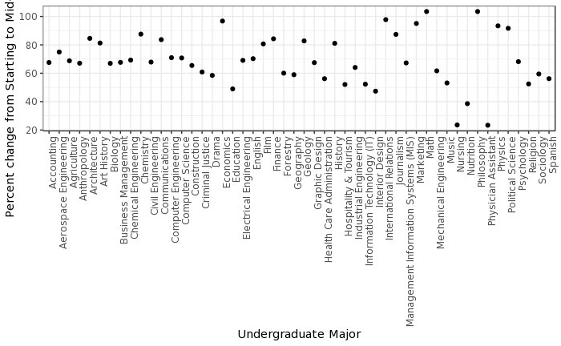

```r
degrees_that_pay_back%>%
  ggplot(aes(x=`Undergraduate Major`,y=`Percent change from Starting to Mid-Career Salary`))+geom_point()+theme_bw() + theme(axis.text.x = element_text(angle = 90, hjust = 1))
```

```r
OccupationProjection<-OccupationProjection%>%
  filter(Average.Annual.Openings>=20000)
OccupationProjection
```

| State.FIPS | Area.Name | Occupation.Code | Occupation.Name | Base.Year | Base | Projected.Year | Projection | Change | Percent.Change | Average.Annual.Openings |
| --- | --- | --- | --- | --- | --- | --- | --- | --- | --- | --- |
| 0 | United States | 11-1021 | General and Operations Managers | 2014 | 2124100 | 2024 | 2275200 | 151100 | 7.1 | 68880 |
| 0 | United States | 11-9199 | Managers, All Other | 2014 | 985600 | 2024 | 1023600 | 38000 | 3.9 | 25540 |
| 0 | United States | 13-1111 | Management Analysts | 2014 | 758000 | 2024 | 861400 | 103400 | 13.6 | 20850 |
| 0 | United States | 13-2011 | Accountants and Auditors | 2014 | 1332700 | 2024 | 1475100 | 142400 | 10.7 | 49800 |
| 0 | United States | 15-1132 | Software Developers, Applications | 2014 | 718400 | 2024 | 853700 | 135300 | 18.8 | 23800 |
| 0 | United States | 25-2021 | Elementary School Teachers, Except Special Education | 2014 | 1358000 | 2024 | 1436300 | 78300 | 5.8 | 37870 |
| 0 | United States | 25-2031 | Secondary School Teachers, Except Special and Career/Technical Education | 2014 | 961600 | 2024 | 1017500 | 55900 | 5.8 | 28400 |
| 0 | United States | 25-3099 | Teachers and Instructors, All Other | 2014 | 982500 | 2024 | 1049000 | 66500 | 6.8 | 25170 |
| 0 | United States | 25-9041 | Teacher Assistants | 2014 | 1234100 | 2024 | 1312800 | 78600 | 6.4 | 37450 |
| 0 | United States | 29-1141 | Registered Nurses | 2014 | 2751000 | 2024 | 3190300 | 439300 | 16.0 | 108840 |

[output cut: 43 more lines]

[figure not shown]

```r
ggplot(data=OccupationProjection,aes(x=Occupation.Name,y=Average.Annual.Openings ))+geom_bar(stat='identity',position='stack', width=.9)+theme_bw() +theme(axis.text.x = element_text(angle = 90, hjust = 1))
```

Shows the top three majors with the highest percent change from starting to mid career salary.

```r
degrees_that_pay_back %>%
  arrange(desc(`Percent change from Starting to Mid-Career Salary`)) %>%
  head(3)
```

| Undergraduate Major | Starting Median Salary | Mid-Career Median Salary | Percent change from Starting to Mid-Career Salary | Mid-Career 10th Percentile Salary | Mid-Career 25th Percentile Salary | Mid-Career 75th Percentile Salary | Mid-Career 90th Percentile Salary |
| --- | --- | --- | --- | --- | --- | --- | --- |
| Math | $45,400.00 | $92,400.00 | 103.5 | $45,200.00 | $64,200.00 | $128,000.00 | $183,000.00 |
| Philosophy | $39,900.00 | $81,200.00 | 103.5 | $35,500.00 | $52,800.00 | $127,000.00 | $168,000.00 |
| International Relations | $40,900.00 | $80,900.00 | 97.8 | $38,200.00 | $56,000.00 | $111,000.00 | $157,000.00 |

Shows three occupations with the highest percentage changes

```r
OccupationProjection %>%
  arrange(desc(Percent.Change)) %>%
  select(Area.Name, Occupation.Name, Percent.Change) %>%
  head(3)
```

|  | Area.Name | Occupation.Name | Percent.Change |
| --- | --- | --- | --- |
| 1 | United States | Home Health Aides | 38.1 |
| 2 | California | Personal Care Aides | 35.8 |
| 3 | California | Combined Food Preparation and Serving Workers, Including Fast Food | 31.3 |

Show that we can change the character strings into numerics and then find a difference between Mid-Career salary and Starting Career salary.

```r
salaries_by_region <-
  salaries_by_region %>%
  mutate(Mid_Career_Median_Salary = as.numeric(gsub('\\$|,', '', `Mid-Career Median Salary`)),
         Starting_Median_Salary = as.numeric(gsub('\\$|,', '', `Starting Median Salary`)),
         Difference = Mid_Career_Median_Salary - Starting_Median_Salary)
salaries_by_region %>%
  select(Mid_Career_Median_Salary, Starting_Median_Salary, Difference)
```

| Mid_Career_Median_Salary | Starting_Median_Salary | Difference |
| --- | --- | --- |
| 129000 | 70400 | 58600 |
| 123000 | 75500 | 47500 |
| 122000 | 71800 | 50200 |
| 112000 | 59900 | 52100 |
| 105000 | 51900 | 53100 |
| 101000 | 57200 | 43800 |
| 101000 | 52600 | 48400 |
| 101000 | 51100 | 49900 |
| 101000 | 48600 | 52400 |
| 99600 | 54800 | 44800 |

[output cut: 310 more lines]

```r
salaries_by_region
```

| School Name | Region | Starting Median Salary | Mid-Career Median Salary | Mid-Career 10th Percentile Salary | Mid-Career 25th Percentile Salary | Mid-Career 75th Percentile Salary | Mid-Career 90th Percentile Salary | Mid_Career_Median_Salary | Starting_Median_Salary | Difference |
| --- | --- | --- | --- | --- | --- | --- | --- | --- | --- | --- |
| Stanford University | California | $70,400.00 | $129,000.00 | $68,400.00 | $93,100.00 | $184,000.00 | $257,000.00 | 129000 | 70400 | 58600 |
| California Institute of Technology (CIT) | California | $75,500.00 | $123,000.00 | N/A | $104,000.00 | $161,000.00 | N/A | 123000 | 75500 | 47500 |
| Harvey Mudd College | California | $71,800.00 | $122,000.00 | N/A | $96,000.00 | $180,000.00 | N/A | 122000 | 71800 | 50200 |
| University of California, Berkeley | California | $59,900.00 | $112,000.00 | $59,500.00 | $81,000.00 | $149,000.00 | $201,000.00 | 112000 | 59900 | 52100 |
| Occidental College | California | $51,900.00 | $105,000.00 | N/A | $54,800.00 | $157,000.00 | N/A | 105000 | 51900 | 53100 |
| Cal Poly San Luis Obispo | California | $57,200.00 | $101,000.00 | $55,000.00 | $74,700.00 | $133,000.00 | $178,000.00 | 101000 | 57200 | 43800 |
| University of California at Los Angeles (UCLA) | California | $52,600.00 | $101,000.00 | $51,300.00 | $72,500.00 | $139,000.00 | $193,000.00 | 101000 | 52600 | 48400 |
| University of California, San Diego (UCSD) | California | $51,100.00 | $101,000.00 | $51,700.00 | $75,400.00 | $131,000.00 | $177,000.00 | 101000 | 51100 | 49900 |
| Pomona College | California | $48,600.00 | $101,000.00 | N/A | $63,300.00 | $161,000.00 | N/A | 101000 | 48600 | 52400 |
| University of Southern California (USC) | California | $54,800.00 | $99,600.00 | $49,700.00 | $73,800.00 | $140,000.00 | $201,000.00 | 99600 | 54800 | 44800 |

[output cut: 310 more lines]